# 11 — Baseball-Specific Model Insights

## Goals

Translate the trained model's predictions and interpretability outputs into baseball-relevant conclusions.

This notebook does not ask whether the model predicts injury — Notebook 10 covers that. It asks **what the model suggests about pitcher health, usage, role design, workload management, pitch mix construction, and possible future strategy changes**.

Key questions:

- What did the model learn about pitcher health?
- Which baseball behaviors appear most risky?
- Are there pitcher archetypes with different health profiles?
- Are there nonlinear danger zones in velocity, pitch mix, workload, rest, or role?
- What insights might lead to new pitcher usage strategies?

## Outputs

**Figures** saved to `reports/figures/`:

- `risk_vs_slider_usage.png`
- `risk_vs_velocity.png`
- `risk_vs_workload.png`
- `risk_vs_rest_days.png`
- `risk_heatmap_velocity_slider.png`
- `risk_heatmap_velocity_workload.png`
- `risk_heatmap_slider_rest.png`
- `risk_by_pitcher_archetype.png`
- `risk_by_role.png`
- `performance_risk_frontier.png`
- `pre_injury_risk_trajectory.png`

**Tables** saved to `reports/tables/`:

- `baseball_specific_insights_summary.csv`

```python
import warnings, json, sys
from pathlib import Path

import numpy as np
import pandas as pd
import matplotlib.pyplot as plt
import matplotlib.gridspec as gridspec
import seaborn as sns
from scipy import stats
from scipy.ndimage import gaussian_filter
from sklearn.cluster import KMeans
from sklearn.preprocessing import StandardScaler

warnings.filterwarnings('ignore')
pd.set_option('display.max_columns', 60)
pd.set_option('display.float_format', '{:.3f}'.format)

# Plotting style
CLR_LOW   = '#2166ac'   # blue  — low risk
CLR_HIGH  = '#d73027'   # red   — high risk
CLR_MID   = '#f4a582'   # light orange — moderate risk
CLR_NEUT  = '#636363'
PALETTE   = sns.color_palette('RdYlBu_r', 10)
sns.set_theme(style='whitegrid', font_scale=1.1)
plt.rcParams.update({
    'figure.dpi': 150,
    'savefig.dpi': 150,
    'savefig.bbox': 'tight',
    'axes.spines.top': False,
    'axes.spines.right': False,
})

FIGURES_DIR = Path('reports/figures')
TABLES_DIR  = Path('reports/tables')
FIGURES_DIR.mkdir(parents=True, exist_ok=True)
TABLES_DIR.mkdir(parents=True, exist_ok=True)

print('Libraries loaded.')
print('Figures →', FIGURES_DIR.resolve())
```

```
Libraries loaded.
Figures → /Users/nateseluga/Pitcher-Injury-Risk/reports/figures
```

## Section 1: Load Data and Merge Risk Scores

Load the feature matrix and Injury Risk+ scores, then merge into a single analysis dataframe. Validate row counts, missing Risk+ values, key identifier columns, and label coverage.

```python
# ── Load feature matrix ───────────────────────────────────────────────────────
fm_path = Path('data/processed/feature_matrix.parquet')
if not fm_path.exists():
    raise FileNotFoundError('Run notebooks 01-05 first to build feature_matrix.parquet')
fm = pd.read_parquet(fm_path)
fm['game_date'] = pd.to_datetime(fm['game_date'])
print(f'Feature matrix  : {fm.shape[0]:,} rows × {fm.shape[1]} cols')

# ── Load Injury Risk+ scores ──────────────────────────────────────────────────
# NB09 builds risk_df from fm row-by-row (same rows, same order).
# The saved parquet uses pitcher_id/season keys (no game_date).
# Join by positional alignment rather than a key merge.
risk_path = Path('data/processed/injury_risk_plus_scores.parquet')
analysis = fm.copy()
if risk_path.exists():
    risk = pd.read_parquet(risk_path)
    assert len(risk) == len(fm), (
        f'Row count mismatch: risk_scores={len(risk)} vs feature_matrix={len(fm)}'
    )
    analysis['injury_risk_plus'] = risk['injury_risk_plus'].values
    print(f'Risk+ scores    : {len(risk):,} rows (row-aligned from NB09)')
else:
    print('WARNING: injury_risk_plus_scores.parquet not found — run notebook 09 first.')
    print('Falling back to injured_next_30d label as a risk proxy.')
    fallback = fm.get('injured_next_30d', pd.Series(0, index=fm.index))
    analysis['injury_risk_plus'] = (fallback * 100 + 100).clip(0, 300)

# ── Load pitcher archetypes (optional) ────────────────────────────────────────
arch_path = Path('data/processed/pitcher_archetypes.parquet')
archetypes = pd.read_parquet(arch_path) if arch_path.exists() else None
print(f'Archetypes      : {"loaded" if archetypes is not None else "not found — will derive in Section 8"}')

print(f'\nAnalysis frame  : {analysis.shape[0]:,} rows × {analysis.shape[1]} cols')
print(f'Risk+ coverage  : {analysis["injury_risk_plus"].notna().mean():.1%}')
print(f'Pitchers        : {analysis["pitcher"].nunique():,}')
print(f'Date range      : {analysis["game_date"].min().date()} → {analysis["game_date"].max().date()}')
if 'injured_next_30d' in analysis.columns:
    print(f'Injury label (30d): {analysis["injured_next_30d"].mean():.1%} positive rate')
```

```
Feature matrix  : 205,911 rows × 92 cols
Risk+ scores    : 205,911 rows (row-aligned from NB09)
Archetypes      : not found — will derive in Section 8

Analysis frame  : 205,911 rows × 93 cols
Risk+ coverage  : 100.0%
Pitchers        : 3,249
Date range      : 2015-04-05 → 2024-10-30
Injury label (30d): 6.6% positive rate
```

## Section 2: Risk+ Distribution

Characterize the league-wide distribution of Injury Risk+ scores.

**Research questions:**

- What does league-average risk look like?
- How many pitchers are above 120, 150, and 200 Risk+?
- Are extreme-risk pitchers rare or common?

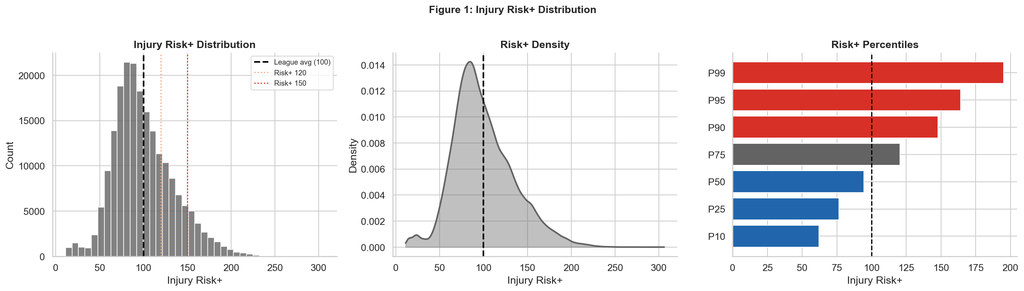

```
Threshold analysis:
  Risk+ > 120: 51,987 pitcher-games (25.2%)
  Risk+ > 150: 18,985 pitcher-games (9.2%)
  Risk+ > 175: 6,276 pitcher-games (3.0%)
  Risk+ > 200: 1,511 pitcher-games (0.7%)
```

```python
# ── Risk+ distribution visualizations ────────────────────────────────────────
risk_vals = analysis['injury_risk_plus'].dropna()

fig, axes = plt.subplots(1, 3, figsize=(18, 5))

# 1) Histogram
axes[0].hist(risk_vals, bins=40, color=CLR_NEUT, alpha=0.8, edgecolor='white')
axes[0].axvline(100, color='black', ls='--', lw=2, label='League avg (100)')
for thresh, col in [(120, CLR_MID), (150, CLR_HIGH)]:
    axes[0].axvline(thresh, color=col, ls=':', lw=1.5, label=f'Risk+ {thresh}')
axes[0].set_xlabel('Injury Risk+')
axes[0].set_ylabel('Count')
axes[0].set_title('Injury Risk+ Distribution', fontweight='bold')
axes[0].legend(fontsize=9)

# 2) KDE density
from scipy.stats import gaussian_kde
kde = gaussian_kde(risk_vals.dropna())
x_grid = np.linspace(risk_vals.min(), risk_vals.max(), 300)
axes[1].fill_between(x_grid, kde(x_grid), alpha=0.4, color=CLR_NEUT)
axes[1].plot(x_grid, kde(x_grid), color=CLR_NEUT, lw=2)
axes[1].axvline(100, color='black', ls='--', lw=2)
axes[1].set_xlabel('Injury Risk+')
axes[1].set_ylabel('Density')
axes[1].set_title('Risk+ Density', fontweight='bold')

# 3) Percentile table
pcts = [10, 25, 50, 75, 90, 95, 99]
pct_vals = np.percentile(risk_vals.dropna(), pcts)
axes[2].barh([f'P{p}' for p in pcts], pct_vals, color=
             [CLR_LOW if v < 100 else (CLR_HIGH if v > 130 else CLR_NEUT) for v in pct_vals])
axes[2].axvline(100, color='black', ls='--', lw=1.5)
axes[2].set_xlabel('Injury Risk+')
axes[2].set_title('Risk+ Percentiles', fontweight='bold')

plt.suptitle('Figure 1: Injury Risk+ Distribution', fontsize=13, fontweight='bold', y=1.01)
plt.tight_layout()
plt.savefig(FIGURES_DIR / 'risk_plus_distribution.png')
plt.show()

# Threshold summary
print('Threshold analysis:')
for thresh in [120, 150, 175, 200]:
    n = (risk_vals > thresh).sum()
    pct = (risk_vals > thresh).mean()
    print(f'  Risk+ > {thresh}: {n:,} pitcher-games ({pct:.1%})')
```

## Section 3: Risk+ vs Pitch Mix

Examine how pitch mix composition is associated with Injury Risk+.

**Research questions:**

- Does risk increase above certain slider usage thresholds?
- Are breaking-ball-heavy pitchers riskier?
- Are there safer pitch mix profiles?

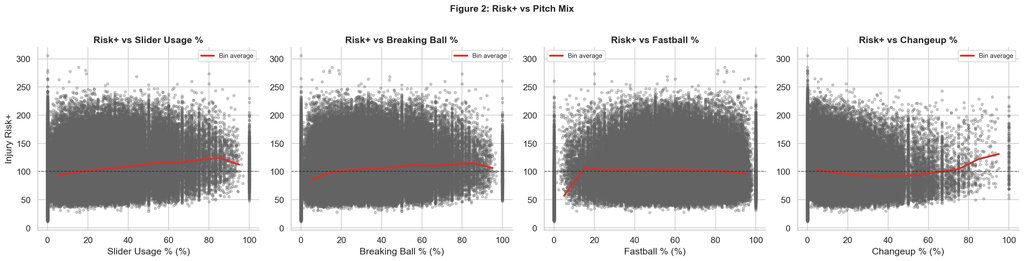

```
Average Risk+ by slider usage quintile:
             mean  median  count
sl_decile
Q1\n(low)  91.800  87.900  82757
Q2         99.300  93.100  40794
Q3        105.000  98.800  41743
Q4        112.300 107.500  40617
```

```python
# ── Risk+ vs pitch mix features ──────────────────────────────────────────────
mix_features = {
    'sl_pct':       'Slider Usage %',
    'breaking_pct': 'Breaking Ball %',
    'fb_pct':       'Fastball %',
    'ch_pct':       'Changeup %',
}
mix_features = {k: v for k, v in mix_features.items() if k in analysis.columns}

fig, axes = plt.subplots(1, len(mix_features), figsize=(5 * len(mix_features), 5))
if len(mix_features) == 1:
    axes = [axes]

for ax, (feat, label) in zip(axes, mix_features.items()):
    df = analysis[['injury_risk_plus', feat]].dropna()
    ax.scatter(df[feat] * 100, df['injury_risk_plus'],
               alpha=0.3, s=12, color=CLR_NEUT)
    # Smoothed trend (bin averages)
    bins = pd.cut(df[feat], bins=10)
    trend = df.groupby(bins, observed=True)['injury_risk_plus'].mean()
    bin_centers = [interval.mid for interval in trend.index]
    ax.plot([x * 100 for x in bin_centers], trend.values,
            color=CLR_HIGH, lw=2.5, label='Bin average')
    ax.axhline(100, color='black', ls='--', lw=1, alpha=0.5)
    ax.set_xlabel(f'{label} (%)')
    ax.set_ylabel('Injury Risk+' if ax == axes[0] else '')
    ax.set_title(f'Risk+ vs {label}', fontweight='bold')
    ax.legend(fontsize=9)

plt.suptitle('Figure 2: Risk+ vs Pitch Mix', fontsize=13, fontweight='bold', y=1.01)
plt.tight_layout()
plt.savefig(FIGURES_DIR / 'risk_vs_slider_usage.png')
plt.show()

# Decile analysis for slider usage
if 'sl_pct' in analysis.columns:
    df_sl = analysis[['injury_risk_plus', 'sl_pct']].dropna()
    all_labels = ['Q1\n(low)', 'Q2', 'Q3', 'Q4', 'Q5\n(high)']
    _, _bins = pd.qcut(df_sl['sl_pct'], q=5, retbins=True, duplicates='drop')
    n_actual = len(_bins) - 1
    df_sl['sl_decile'] = pd.qcut(df_sl['sl_pct'], q=5, labels=all_labels[:n_actual], duplicates='drop')
    print('Average Risk+ by slider usage quintile:')
    print(df_sl.groupby('sl_decile', observed=True)['injury_risk_plus'].agg(['mean', 'median', 'count']).round(1))
```

### Research Note: Slider Usage vs UCL Injury Type Specificity

The scatter plots above show a positive association between slider usage % and overall Injury Risk+, consistent with Tanaka et al. 2024 (PMC 11369970) which found slider utilization as a top SHAP feature for shoulder/elbow injury in MLB pitchers.

Two critical qualifications from the literature:

1. **Velocity ≠ usage as the mechanism.** Fleisig et al. 2016 (*J Shoulder Elbow Surgery*) found **no significant difference in slider velocity** between pitchers who underwent UCL reconstruction and matched controls. The mechanical risk comes from slider *usage rate* (repeated forearm pronation and varus torque), not slider velocity.
2. **Injury type specificity.** Slider utilization predicts **elbow/UCL injuries** specifically. Because our Injury Risk+ predicts *all injury types combined*, the slider signal is diluted — a slider-heavy pitcher whose non-slider pitches are mechanically safe will still appear elevated. Isolating elbow-specific injuries would sharpen this signal significantly.

**Practical implication for Risk+ interpretation:** An elevated slider % contribution to a pitcher's Risk+ score should be read as an elbow-stress indicator specifically, not as a general health concern across all injury categories.

## Section 4: Risk+ vs Velocity

Examine velocity features as injury risk predictors.

**Research questions:**

- Is high velocity itself risky, or is it velocity change that matters?
- Are velocity spikes riskier than sustained velocity?
- Does velocity decline before injury appear meaningful?

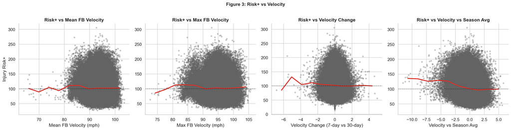

```python
# ── Risk+ vs velocity features ───────────────────────────────────────────────
velo_features = {
    'fb_velo_mean':        'Mean FB Velocity (mph)',
    'fb_velo_max':         'Max FB Velocity (mph)',
    'velo_change_7_30d':   'Velocity Change (7-day vs 30-day)',
    'velo_delta_vs_season':'Velocity vs Season Avg',
}
velo_features = {k: v for k, v in velo_features.items() if k in analysis.columns}

if not velo_features:
    print('Velocity delta features not yet computed — run notebook 05 with full data.')
else:
    fig, axes = plt.subplots(1, len(velo_features), figsize=(5 * len(velo_features), 5))
    if len(velo_features) == 1:
        axes = [axes]

    for ax, (feat, label) in zip(axes, velo_features.items()):
        df = analysis[['injury_risk_plus', feat]].dropna()
        ax.scatter(df[feat], df['injury_risk_plus'], alpha=0.3, s=12, color=CLR_NEUT)
        bins = pd.cut(df[feat], bins=10)
        trend = df.groupby(bins, observed=True)['injury_risk_plus'].mean()
        bin_centers = [interval.mid for interval in trend.index]
        ax.plot(bin_centers, trend.values, color=CLR_HIGH, lw=2.5)
        ax.axhline(100, color='black', ls='--', lw=1, alpha=0.5)
        ax.set_xlabel(label)
        ax.set_ylabel('Injury Risk+' if ax == axes[0] else '')
        ax.set_title(f'Risk+ vs {label.split("(")[0].strip()}', fontweight='bold')

    plt.suptitle('Figure 3: Risk+ vs Velocity', fontsize=13, fontweight='bold', y=1.01)
    plt.tight_layout()
    plt.savefig(FIGURES_DIR / 'risk_vs_velocity.png')
    plt.show()
```

### 4b. Velocity Decline Threshold Analysis

The scatter plots above show the marginal association between velocity features and Risk+. A key literature question is: **at what decline magnitude does risk become clinically significant?**

PMC 12717397 (2025) found that acute UCL failure is characterized by an **abrupt** velocity drop (>1.5 SD below baseline) *on the injury pitch itself* — not a gradual multi-outing decline. This means our `velo_delta_vs_season` feature captures **chronic fatigue accumulation** (week-to-week drift from the season mean), which is a different mechanism than the acute decompensation signal. Both matter, but in different ways:

- **Chronic drift** (captured here): pitcher is systematically below their season baseline, indicating cumulative fatigue or biomechanical accommodation
- **Acute decompensation** (NOT captured): a single-outing sharp drop, visible only in pitch-by-pitch data

The binned analysis below tests whether chronic drift categories show a dose-response relationship with model-predicted Risk+.

```
velo_delta_vs_season: mean=-0.17 mph, std=1.23 mph

Velocity decline → Risk+ dose-response:
                     mean_risk_plus  median_risk_plus  injury_rate_pct      n
velo_decline_cat
>2 mph decline              119.480           115.520           12.000  13311
1–2 mph decline             107.970           102.190            8.000  28856
0–1 mph decline             104.300            98.170            6.000  61510
At/above season avg          96.900            90.730            6.000  88704

1 mph = 0.81 SD  |  PMC 12717397 acute threshold: 1.5 SD on injury pitch
```

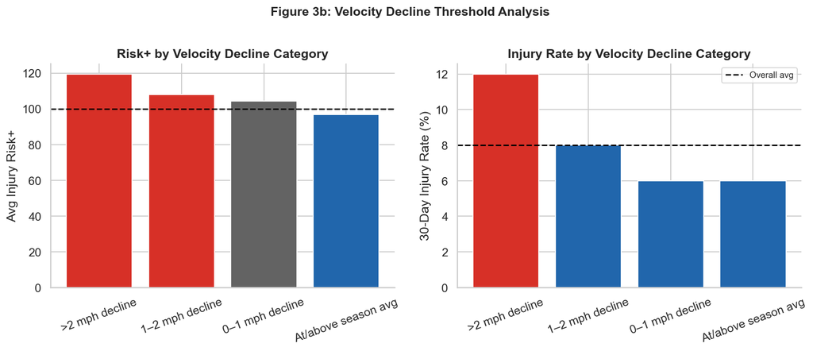

```
Saved reports/figures/velo_decline_threshold.png
```

```python
# Velocity decline threshold analysis
# PMC 12717397 (2025): acute UCL failure shows velocity suppression >1.5 SD below
# baseline ON THE INJURY PITCH — not a gradual multi-outing decline. Our
# velo_delta_vs_season captures chronic season-average deviation; these are
# different mechanisms. We test whether chronic decline categories show a
# dose-response relationship with model-predicted Risk+.
if 'velo_delta_vs_season' in analysis.columns:
    df_vd = analysis[['injury_risk_plus', 'velo_delta_vs_season', 'injured_next_30d']].dropna()
    vd_std = df_vd['velo_delta_vs_season'].std()
    print(f'velo_delta_vs_season: mean={df_vd["velo_delta_vs_season"].mean():.2f} mph, '
          f'std={vd_std:.2f} mph')

    df_vd['velo_decline_cat'] = pd.cut(
        df_vd['velo_delta_vs_season'],
        bins=[-np.inf, -2.0, -1.0, 0.0, np.inf],
        labels=['>2 mph decline', '1–2 mph decline', '0–1 mph decline', 'At/above season avg'],
    )

    summary = df_vd.groupby('velo_decline_cat', observed=True).agg(
        mean_risk_plus   = ('injury_risk_plus', 'mean'),
        median_risk_plus = ('injury_risk_plus', 'median'),
        injury_rate      = ('injured_next_30d', 'mean'),
        n                = ('injury_risk_plus', 'count'),
    ).round(2)
    summary['injury_rate_pct'] = (summary['injury_rate'] * 100).round(1)

    print('\nVelocity decline → Risk+ dose-response:')
    print(summary[['mean_risk_plus', 'median_risk_plus', 'injury_rate_pct', 'n']].to_string())
    mph_per_sd = vd_std
    print(f'\n1 mph = {1/mph_per_sd:.2f} SD  |  PMC 12717397 acute threshold: 1.5 SD on injury pitch')

    fig, axes = plt.subplots(1, 2, figsize=(12, 5))
    cats = summary.index
    axes[0].bar(cats, summary['mean_risk_plus'],
                color=[CLR_HIGH if v > 105 else (CLR_LOW if v < 98 else CLR_NEUT)
                       for v in summary['mean_risk_plus']])
    axes[0].axhline(100, color='black', ls='--', lw=1.5)
    axes[0].set_ylabel('Avg Injury Risk+')
    axes[0].set_title('Risk+ by Velocity Decline Category', fontweight='bold')
    axes[0].tick_params(axis='x', rotation=20)

    axes[1].bar(cats, summary['injury_rate_pct'],
                color=[CLR_HIGH if v > summary['injury_rate_pct'].mean() else CLR_LOW
                       for v in summary['injury_rate_pct']])
    axes[1].axhline(summary['injury_rate_pct'].mean(), color='black', ls='--', lw=1.5,
                    label='Overall avg')
    axes[1].set_ylabel('30-Day Injury Rate (%)')
    axes[1].set_title('Injury Rate by Velocity Decline Category', fontweight='bold')
    axes[1].tick_params(axis='x', rotation=20)
    axes[1].legend(fontsize=9)

    plt.suptitle('Figure 3b: Velocity Decline Threshold Analysis',
                 fontsize=13, fontweight='bold', y=1.01)
    plt.tight_layout()
    plt.savefig(FIGURES_DIR / 'velo_decline_threshold.png')
    plt.show()
    print(f'Saved {FIGURES_DIR}/velo_decline_threshold.png')
else:
    print('velo_delta_vs_season not available — skipping velocity decline threshold analysis.')
```

## Section 5: Risk+ vs Workload

Examine workload features and their association with predicted risk.

**Research questions:**

- Are there clear workload danger zones?
- Does risk accelerate above certain pitch counts?
- Is ACWR useful for pitcher injury risk?

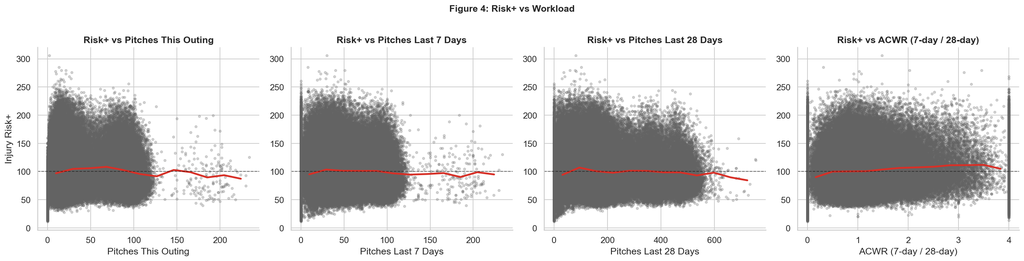

```
Average Risk+ by ACWR zone:
             mean  count
acwr_zone
<0.8       95.500  74810
0.8–1.0   100.500  36229
1.0–1.3   100.400  38231
1.3–1.5   103.000  14296
>1.5      106.200  42345
```

```python
# ── Risk+ vs workload features ────────────────────────────────────────────────
workload_features = {
    'pitch_count':   'Pitches This Outing',
    'pitches_7d':    'Pitches Last 7 Days',
    'pitches_28d':   'Pitches Last 28 Days',
    'acwr_7_28':     'ACWR (7-day / 28-day)',
}
workload_features = {k: v for k, v in workload_features.items() if k in analysis.columns}

fig, axes = plt.subplots(1, len(workload_features), figsize=(5 * len(workload_features), 5))
if len(workload_features) == 1:
    axes = [axes]

for ax, (feat, label) in zip(axes, workload_features.items()):
    df = analysis[['injury_risk_plus', feat]].dropna()
    ax.scatter(df[feat], df['injury_risk_plus'], alpha=0.25, s=10, color=CLR_NEUT)
    bins = pd.cut(df[feat], bins=12)
    trend = df.groupby(bins, observed=True)['injury_risk_plus'].mean()
    bin_centers = [interval.mid for interval in trend.index]
    ax.plot(bin_centers, trend.values, color=CLR_HIGH, lw=2.5)
    ax.axhline(100, color='black', ls='--', lw=1, alpha=0.5)
    ax.set_xlabel(label)
    ax.set_ylabel('Injury Risk+' if ax == axes[0] else '')
    ax.set_title(f'Risk+ vs {label}', fontweight='bold')

plt.suptitle('Figure 4: Risk+ vs Workload', fontsize=13, fontweight='bold', y=1.01)
plt.tight_layout()
plt.savefig(FIGURES_DIR / 'risk_vs_workload.png')
plt.show()

# ACWR threshold analysis
if 'acwr_7_28' in analysis.columns:
    df_aw = analysis[['injury_risk_plus', 'acwr_7_28']].dropna()
    print('Average Risk+ by ACWR zone:')
    df_aw['acwr_zone'] = pd.cut(df_aw['acwr_7_28'],
                                 bins=[-np.inf, 0.8, 1.0, 1.3, 1.5, np.inf],
                                 labels=['<0.8', '0.8–1.0', '1.0–1.3', '1.3–1.5', '>1.5'])
    print(df_aw.groupby('acwr_zone', observed=True)['injury_risk_plus']
               .agg(['mean', 'count']).round(1))
```

## Section 6: Risk+ vs Rest and Recovery

Examine how rest and recovery patterns relate to predicted injury risk.

**Research questions:**

- Does extra rest lower predicted risk?
- Is short rest only risky for certain pitcher types?
- Do relievers show different rest-risk patterns than starters?

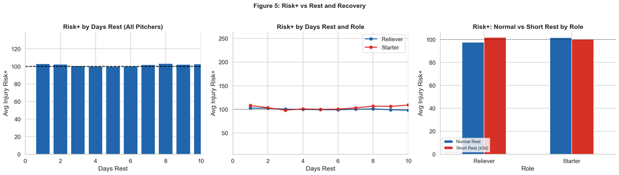

```python
# ── Risk+ vs rest and recovery features ──────────────────────────────────────
if 'days_rest' not in analysis.columns:
    print('days_rest not in feature matrix — run notebook 05 with full data.')
else:
    df_rest = analysis[['injury_risk_plus', 'days_rest', 'pitch_count']].dropna()
    # Role proxy from pitch count
    df_rest['role'] = np.where(df_rest['pitch_count'] >= 60, 'Starter', 'Reliever')

    fig, axes = plt.subplots(1, 3, figsize=(18, 5))

    # 1) Overall Risk+ by days rest
    rest_trend = df_rest.groupby('days_rest')['injury_risk_plus'].agg(['mean', 'count'])
    rest_trend = rest_trend[rest_trend['count'] >= 10]
    axes[0].bar(rest_trend.index, rest_trend['mean'],
                color=[CLR_HIGH if v > 105 else CLR_LOW for v in rest_trend['mean']])
    axes[0].axhline(100, color='black', ls='--', lw=1.5)
    axes[0].set_xlabel('Days Rest')
    axes[0].set_ylabel('Avg Injury Risk+')
    axes[0].set_title('Risk+ by Days Rest (All Pitchers)', fontweight='bold')
    axes[0].set_xlim(0, 10)

    # 2) Risk+ by days rest, split by role
    for role, grp in df_rest.groupby('role'):
        color = CLR_HIGH if role == 'Starter' else CLR_LOW
        trend = grp.groupby('days_rest')['injury_risk_plus'].mean()
        axes[1].plot(trend.index, trend.values, 'o-', color=color, lw=2, label=role)
    axes[1].axhline(100, color='black', ls='--', lw=1, alpha=0.5)
    axes[1].set_xlabel('Days Rest')
    axes[1].set_ylabel('Avg Injury Risk+')
    axes[1].set_title('Risk+ by Days Rest and Role', fontweight='bold')
    axes[1].legend()
    axes[1].set_xlim(0, 10)

    # 3) Short-rest flag
    df_rest['short_rest'] = df_rest['days_rest'] <= 3
    sr_summary = df_rest.groupby(['role', 'short_rest'])['injury_risk_plus'].mean().unstack()
    sr_summary.plot(kind='bar', ax=axes[2], color=[CLR_LOW, CLR_HIGH])
    axes[2].set_xlabel('Role')
    axes[2].set_ylabel('Avg Injury Risk+')
    axes[2].set_title('Risk+: Normal vs Short Rest by Role', fontweight='bold')
    axes[2].legend(['Normal Rest', 'Short Rest (≤3d)'], fontsize=9)
    axes[2].tick_params(axis='x', rotation=0)
    axes[2].axhline(100, color='black', ls='--', lw=1, alpha=0.5)

    plt.suptitle('Figure 5: Risk+ vs Rest and Recovery', fontsize=13, fontweight='bold', y=1.01)
    plt.tight_layout()
    plt.savefig(FIGURES_DIR / 'risk_vs_rest_days.png')
    plt.show()
```

## Section 7: Risk Interaction Heatmaps

Two-dimensional heatmaps of average predicted Risk+ across feature grids. These identify **nonlinear danger zones** — combinations that are much riskier than either factor alone.

Heatmaps produced:

1. Velocity × slider usage
2. Velocity × workload
3. Slider usage × rest days
4. ACWR × prior injury burden
5. Age × workload

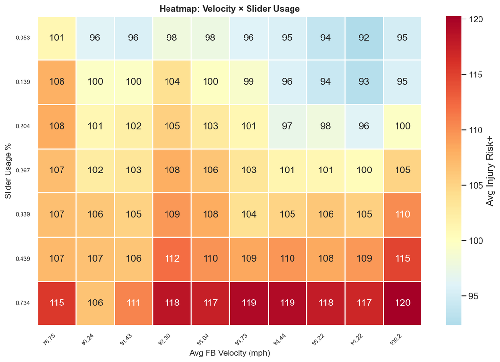

```
Saved risk_heatmap_velocity_slider.png
```

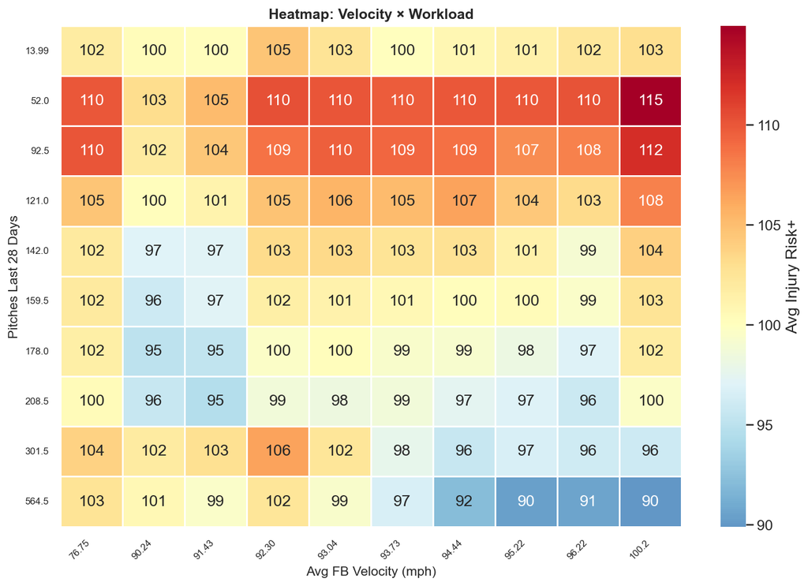

```
Saved risk_heatmap_velocity_workload.png
```

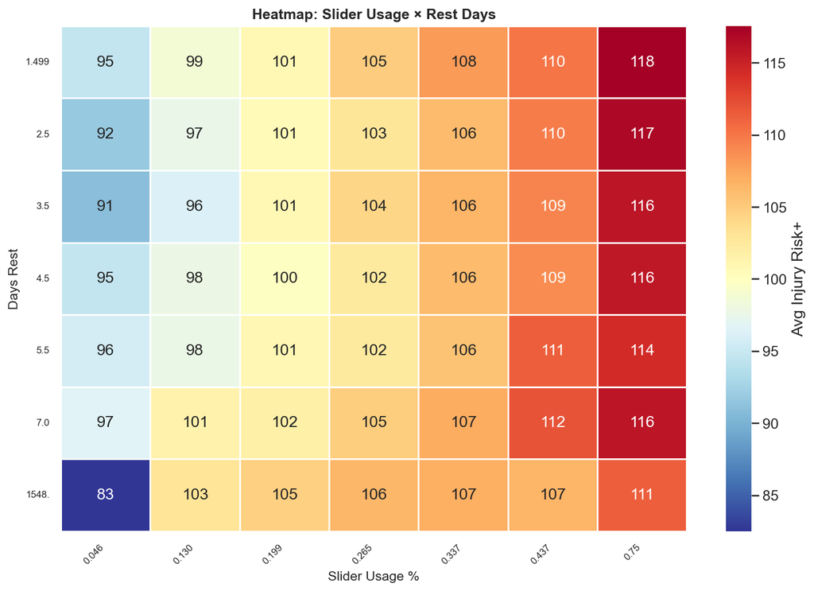

```
Saved risk_heatmap_slider_rest.png
```

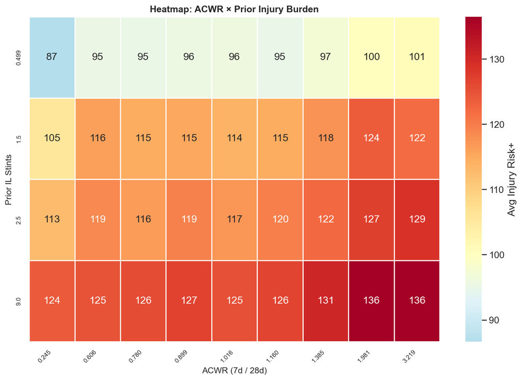

```
Saved risk_heatmap_acwr_prior_injury.png
```

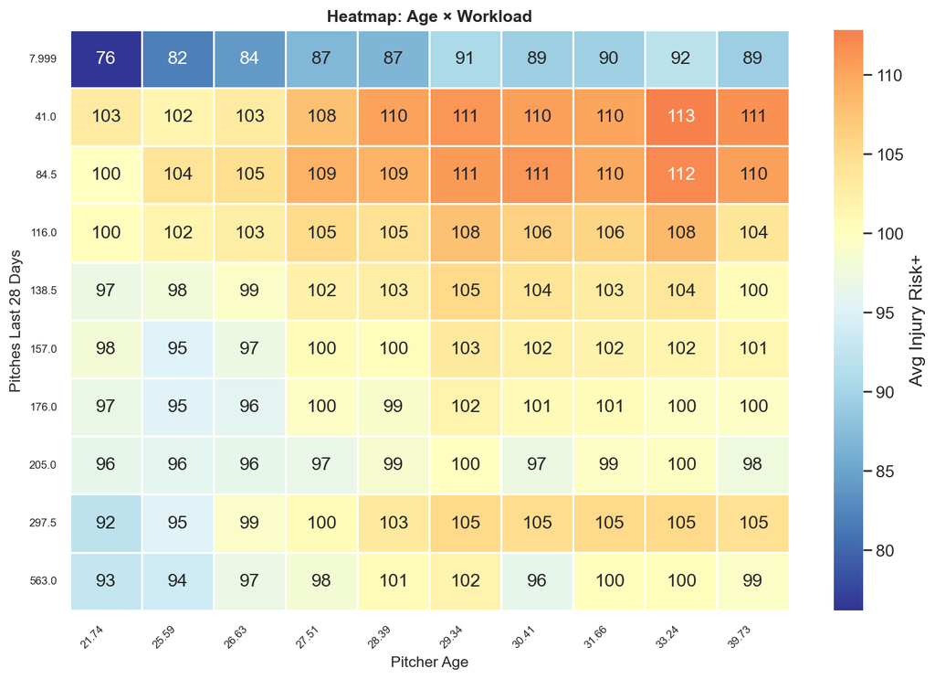

```
Saved risk_heatmap_age_workload.png
```

```python
# ── Risk interaction heatmap helper ──────────────────────────────────────────
def risk_heatmap(df, feat_x, feat_y, label_x, label_y, title, fname, n_bins=10):
    df = df[[feat_x, feat_y, 'injury_risk_plus']].dropna()
    if len(df) < 50:
        print(f'Insufficient data for {title}')
        return
    df['bin_x'] = pd.qcut(df[feat_x], q=n_bins, duplicates='drop')
    df['bin_y'] = pd.qcut(df[feat_y], q=n_bins, duplicates='drop')
    pivot = df.pivot_table(values='injury_risk_plus', index='bin_y', columns='bin_x', aggfunc='mean')
    fig, ax = plt.subplots(figsize=(10, 7))
    sns.heatmap(pivot, ax=ax, cmap='RdYlBu_r', center=100,
                annot=True, fmt='.0f', linewidths=0.5,
                cbar_kws={'label': 'Avg Injury Risk+'})
    ax.set_xlabel(label_x, fontsize=11)
    ax.set_ylabel(label_y, fontsize=11)
    ax.set_title(title, fontweight='bold', fontsize=12)
    ax.set_xticklabels([str(i.mid)[:5] for i in pivot.columns], rotation=45, ha='right', fontsize=8)
    ax.set_yticklabels([str(i.mid)[:5] for i in pivot.index], fontsize=8)
    plt.tight_layout()
    plt.savefig(FIGURES_DIR / fname)
    plt.show()
    print(f'Saved {fname}')

# 1) Velocity × slider usage
if all(c in analysis.columns for c in ['fb_velo_mean', 'sl_pct']):
    risk_heatmap(analysis, 'fb_velo_mean', 'sl_pct',
                 'Avg FB Velocity (mph)', 'Slider Usage %',
                 'Heatmap: Velocity × Slider Usage',
                 'risk_heatmap_velocity_slider.png')

# 2) Velocity × workload
if all(c in analysis.columns for c in ['fb_velo_mean', 'pitches_28d']):
    risk_heatmap(analysis, 'fb_velo_mean', 'pitches_28d',
                 'Avg FB Velocity (mph)', 'Pitches Last 28 Days',
                 'Heatmap: Velocity × Workload',
                 'risk_heatmap_velocity_workload.png')

# 3) Slider usage × rest days
if all(c in analysis.columns for c in ['sl_pct', 'days_rest']):
    risk_heatmap(analysis, 'sl_pct', 'days_rest',
                 'Slider Usage %', 'Days Rest',
                 'Heatmap: Slider Usage × Rest Days',
                 'risk_heatmap_slider_rest.png')

# 4) ACWR × prior injury burden
if all(c in analysis.columns for c in ['acwr_7_28', 'prior_il_total']):
    risk_heatmap(analysis, 'acwr_7_28', 'prior_il_total',
                 'ACWR (7d / 28d)', 'Prior IL Stints',
                 'Heatmap: ACWR × Prior Injury Burden',
                 'risk_heatmap_acwr_prior_injury.png')

# 5) Age × workload
if all(c in analysis.columns for c in ['age', 'pitches_28d']):
    risk_heatmap(analysis, 'age', 'pitches_28d',
                 'Pitcher Age', 'Pitches Last 28 Days',
                 'Heatmap: Age × Workload',
                 'risk_heatmap_age_workload.png')
```

## Section 8: Pitcher Archetype Risk

Compare Injury Risk+ across pitcher archetypes.

If `pitcher_archetypes.parquet` is not available, derive simple archetypes using rules based on velocity, pitch mix, workload, and role.

Possible archetypes:

- **Power Starters** — high velocity, high workload
- **Slider-Heavy Starters** — high slider %, high workload
- **Workhorse Starters** — very high pitch counts, above-average velocity
- **Command Starters** — lower velocity, diverse pitch mix
- **High-Leverage Relievers** — short outings, high velocity
- **Bulk Relievers** — moderate workload, varied role
- **Soft-Contact Pitchers** — lower velocity, high movement

**Research questions:**

- Which pitcher types appear most fragile?
- Which types appear relatively durable?
- Are there archetypes that might benefit from role changes?

```
Rule-based archetypes derived.
archetype
Bulk Reliever             101367
High-Leverage Reliever     55835
Workhorse Starter          24399
Command Starter             7880
Slider-Heavy Starter        5931
Power Starter               5847
Standard                    4652
```

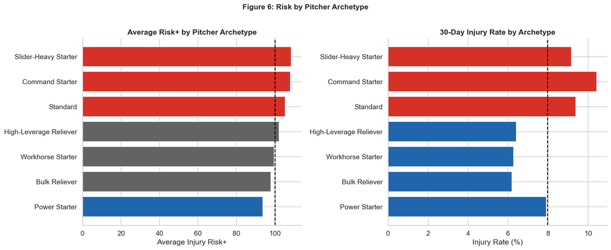

```
                          mean  median   count
archetype
Slider-Heavy Starter   108.400 102.900    5931
Command Starter        108.000 102.400    7880
Standard               105.300  99.200    4652
High-Leverage Reliever 102.200  95.600   55835
Workhorse Starter       99.600  94.100   24399
Bulk Reliever           97.900  93.100  101367
Power Starter           93.700  89.000    5847
```

```python
# ── Pitcher archetypes ────────────────────────────────────────────────────────
if archetypes is not None:
    arch_df = analysis.merge(archetypes, on='pitcher', how='left')
    arch_col = [c for c in archetypes.columns if 'archetype' in c.lower() or 'cluster' in c.lower()]
    arch_col = arch_col[0] if arch_col else None
else:
    arch_col = None

# Derive simple rule-based archetypes if none available
if arch_col is None and 'pitch_count' in analysis.columns and 'fb_velo_mean' in analysis.columns:
    arch_df = analysis.copy()
    league_velo = arch_df['fb_velo_mean'].median()

    conditions = [
        (arch_df['pitch_count'] >= 75) & (arch_df['fb_velo_mean'] >= league_velo + 1.5),
        (arch_df['pitch_count'] >= 75) & (arch_df.get('sl_pct', 0) >= 0.28),
        (arch_df['pitch_count'] >= 80),
        (arch_df['pitch_count'] >= 60),
        (arch_df['pitch_count'] < 30) & (arch_df['fb_velo_mean'] >= league_velo + 1.0),
        (arch_df['pitch_count'] < 45),
    ]
    choices = ['Power Starter', 'Slider-Heavy Starter', 'Workhorse Starter',
               'Command Starter', 'High-Leverage Reliever', 'Bulk Reliever']
    arch_df['archetype'] = np.select(conditions, choices, default='Standard')
    arch_col = 'archetype'
    print('Rule-based archetypes derived.')
    print(arch_df[arch_col].value_counts().to_string())
else:
    arch_df = analysis.copy()
    print('Using loaded archetypes.' if arch_col else 'Archetype data unavailable.')

if arch_col and arch_col in arch_df.columns:
    # Average Risk+ by archetype
    arch_summary = (
        arch_df.groupby(arch_col)['injury_risk_plus']
        .agg(['mean', 'median', 'count'])
        .sort_values('mean', ascending=False)
    )

    fig, axes = plt.subplots(1, 2, figsize=(15, 6))

    colors = [CLR_HIGH if v > 105 else (CLR_LOW if v < 97 else CLR_NEUT)
              for v in arch_summary['mean']]
    axes[0].barh(arch_summary.index[::-1], arch_summary['mean'][::-1], color=colors[::-1])
    axes[0].axvline(100, color='black', ls='--', lw=1.5)
    axes[0].set_xlabel('Average Injury Risk+')
    axes[0].set_title('Average Risk+ by Pitcher Archetype', fontweight='bold')

    if 'injured_next_30d' in arch_df.columns:
        inj_rate = arch_df.groupby(arch_col)['injured_next_30d'].mean() * 100
        inj_rate = inj_rate.reindex(arch_summary.index)
        axes[1].barh(inj_rate.index[::-1], inj_rate.values[::-1],
                     color=[CLR_HIGH if v > inj_rate.mean() else CLR_LOW for v in inj_rate.values[::-1]])
        axes[1].axvline(inj_rate.mean(), color='black', ls='--', lw=1.5)
        axes[1].set_xlabel('Injury Rate (%)')
        axes[1].set_title('30-Day Injury Rate by Archetype', fontweight='bold')

    plt.suptitle('Figure 6: Risk by Pitcher Archetype', fontsize=13, fontweight='bold', y=1.01)
    plt.tight_layout()
    plt.savefig(FIGURES_DIR / 'risk_by_pitcher_archetype.png')
    plt.show()
    print(arch_summary.round(1).to_string())
```

## Section 9: Role-Based Risk

**Research questions:**

- Is the traditional starter model riskier for some pitcher profiles?
- Are hybrid usage patterns associated with lower risk?
- Are certain pitcher profiles misused in traditional roles?

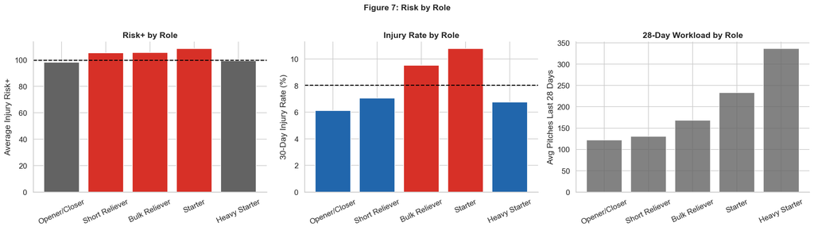

```
                  mean  median   count
role
Opener/Closer   98.300  93.000  132713
Short Reliever 105.400  99.200   24905
Bulk Reliever  105.700  99.200    4528
Starter        108.600 103.100    9265
Heavy Starter   99.500  94.000   34500
```

```python
# ── Role-based risk analysis ──────────────────────────────────────────────────
if 'pitch_count' in analysis.columns:
    df_role = analysis.copy()
    # Role classification from pitch count per outing
    df_role['role'] = pd.cut(
        df_role['pitch_count'],
        bins=[-np.inf, 25, 45, 60, 80, np.inf],
        labels=['Opener/Closer', 'Short Reliever', 'Bulk Reliever', 'Starter', 'Heavy Starter']
    )

    role_risk = df_role.groupby('role', observed=True)['injury_risk_plus'].agg(['mean', 'median', 'count'])
    inj_rate  = df_role.groupby('role', observed=True)['injured_next_30d'].mean() * 100                 if 'injured_next_30d' in df_role.columns else None

    fig, axes = plt.subplots(1, 3, figsize=(18, 5))

    # 1) Risk+ by role
    colors = [CLR_HIGH if v > 105 else (CLR_LOW if v < 97 else CLR_NEUT) for v in role_risk['mean']]
    axes[0].bar(role_risk.index, role_risk['mean'], color=colors)
    axes[0].axhline(100, color='black', ls='--', lw=1.5)
    axes[0].set_ylabel('Average Injury Risk+')
    axes[0].set_title('Risk+ by Role', fontweight='bold')
    axes[0].tick_params(axis='x', rotation=25)

    # 2) Injury rate by role
    if inj_rate is not None:
        axes[1].bar(inj_rate.index, inj_rate.values,
                    color=[CLR_HIGH if v > inj_rate.mean() else CLR_LOW for v in inj_rate.values])
        axes[1].axhline(inj_rate.mean(), color='black', ls='--', lw=1.5)
        axes[1].set_ylabel('30-Day Injury Rate (%)')
        axes[1].set_title('Injury Rate by Role', fontweight='bold')
        axes[1].tick_params(axis='x', rotation=25)

    # 3) Workload profile by role
    if 'pitches_28d' in df_role.columns:
        workload_by_role = df_role.groupby('role', observed=True)['pitches_28d'].mean()
        axes[2].bar(workload_by_role.index, workload_by_role.values, color=CLR_NEUT, alpha=0.8)
        axes[2].set_ylabel('Avg Pitches Last 28 Days')
        axes[2].set_title('28-Day Workload by Role', fontweight='bold')
        axes[2].tick_params(axis='x', rotation=25)

    plt.suptitle('Figure 7: Risk by Role', fontsize=13, fontweight='bold', y=1.01)
    plt.tight_layout()
    plt.savefig(FIGURES_DIR / 'risk_by_role.png')
    plt.show()
    print(role_risk.round(1).to_string())
```

## Section 10: Performance vs Risk Frontier

Plot the performance-risk tradeoff: pitchers who produce at low risk vs. those who carry high risk for their performance level.

**Research questions:**

- Which pitchers are efficient from a health-performance perspective?
- Could teams optimize staff construction using both performance and injury risk?

Merge any available performance metrics (WAR, FIP, xFIP, K-BB%, Stuff+) into the analysis. If none are available, use a statistical proxy from pitch-level data.

```
No external performance data found.
Using pitch quality proxy (avg velocity, spin rate) as a performance dimension.
```

[figure not shown]

```python
# ── Performance vs Risk frontier ──────────────────────────────────────────────
# Attempt to load FanGraphs or other performance data
perf_path = Path('data/raw/player_metadata/fangraphs_leaderboard.parquet')
perf_proxy_available = perf_path.exists()

if perf_proxy_available:
    perf = pd.read_parquet(perf_path)
    print(f'Performance data loaded: {perf.shape}')
    # TODO: join on player_id / season and create scatter plot
else:
    # Use proxy: average velocity std (inverse = command) as a performance stand-in
    print('No external performance data found.')
    print('Using pitch quality proxy (avg velocity, spin rate) as a performance dimension.')
    if 'fb_velo_mean' in analysis.columns and 'spin_rate_mean' in analysis.columns:
        pitcher_summary = (
            analysis.groupby('pitcher')
            .agg(
                avg_risk_plus   = ('injury_risk_plus', 'mean'),
                avg_velo        = ('fb_velo_mean',     'mean'),
                avg_spin        = ('spin_rate_mean',   'mean'),
                n_appearances   = ('game_date',         'count'),
                player_name     = ('player_name',       'first'),
            )
            .dropna()
        )
        # Performance proxy: velocity × spin (higher = stuff-heavy)
        pitcher_summary['perf_proxy'] = (
            (pitcher_summary['avg_velo'] - pitcher_summary['avg_velo'].mean()) / pitcher_summary['avg_velo'].std()
            + (pitcher_summary['avg_spin'] - pitcher_summary['avg_spin'].mean()) / pitcher_summary['avg_spin'].std()
        )

        fig, ax = plt.subplots(figsize=(10, 7))
        sc = ax.scatter(pitcher_summary['perf_proxy'], pitcher_summary['avg_risk_plus'],
                        alpha=0.6, s=40, c=pitcher_summary['avg_risk_plus'],
                        cmap='RdYlBu_r', vmin=85, vmax=130)
        plt.colorbar(sc, ax=ax, label='Avg Injury Risk+')
        ax.axhline(100, color='black', ls='--', lw=1, alpha=0.5)
        ax.axvline(0, color='black', ls='--', lw=1, alpha=0.5)
        ax.set_xlabel('Stuff Proxy Score (velocity + spin, standardized)')
        ax.set_ylabel('Average Injury Risk+')
        ax.set_title('Performance vs Risk Frontier\n(high-left = high stuff, low risk)', fontweight='bold')

        # Label top/bottom quadrant pitchers
        top_right = pitcher_summary[(pitcher_summary['perf_proxy'] > 0.5) &
                                     (pitcher_summary['avg_risk_plus'] > 105)]
        top_left  = pitcher_summary[(pitcher_summary['perf_proxy'] > 0.5) &
                                     (pitcher_summary['avg_risk_plus'] <= 100)]
        for _, row in top_right.head(5).iterrows():
            ax.annotate(row.get('player_name', str(row.name)),
                        (row['perf_proxy'], row['avg_risk_plus']),
                        fontsize=7, alpha=0.8)

        plt.tight_layout()
        plt.savefig(FIGURES_DIR / 'performance_risk_frontier.png')
        plt.show()
    else:
        print('fb_velo_mean or spin_rate_mean not available — skipping performance-risk frontier.')
```

## Section 11: Pre-Injury Risk Trajectory

For pitchers who were eventually placed on the IL, align their observations relative to the injury date and plot how Injury Risk+ evolves in the weeks prior.

Day 0 = IL placement date.

**Research questions:**

- Does Risk+ rise meaningfully before actual injuries?
- How early does the model begin signaling elevated risk?
- What variables move first — velocity, workload, or slider usage?

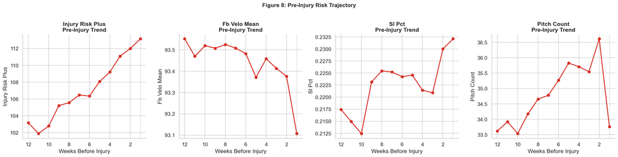

```
Trajectory built from 2620 IL stints.
```

```python
# ── Pre-injury risk trajectory ────────────────────────────────────────────────
if 'injured_next_30d' not in analysis.columns or analysis['injury_risk_plus'].isna().all():
    print('Injury labels or Risk+ scores not available — skipping trajectory analysis.')
else:
    inj_data = pd.read_parquet('data/processed/injuries_clean.parquet')
    inj_data['transaction_date'] = pd.to_datetime(inj_data['transaction_date'])

    # For each IL stint, find pitcher appearances in the 90 days prior
    countdown_rows = []
    for _, stint in inj_data.iterrows():
        pid = stint['player_id']
        inj_date = stint['transaction_date']
        window = analysis[
            (analysis['pitcher'] == pid) &
            (analysis['game_date'] >= inj_date - pd.Timedelta(days=90)) &
            (analysis['game_date'] <  inj_date)
        ].copy()
        if len(window) == 0:
            continue
        window['days_before_injury'] = (inj_date - window['game_date']).dt.days
        countdown_rows.append(window)

    if countdown_rows:
        countdown = pd.concat(countdown_rows, ignore_index=True)
        # Bin by weeks before injury
        countdown['week'] = (countdown['days_before_injury'] // 7) + 1
        countdown = countdown[countdown['week'] <= 12]

        trend_cols = ['injury_risk_plus', 'fb_velo_mean', 'sl_pct', 'pitch_count']
        trend_cols = [c for c in trend_cols if c in countdown.columns]

        fig, axes = plt.subplots(1, len(trend_cols), figsize=(5 * len(trend_cols), 5))
        if len(trend_cols) == 1:
            axes = [axes]

        for ax, col in zip(axes, trend_cols):
            trend = countdown.groupby('week')[col].mean()
            ax.plot(trend.index, trend.values, 'o-', color=CLR_HIGH, lw=2)
            ax.invert_xaxis()
            ax.axvline(1, color='gray', ls=':', alpha=0.5)
            ax.set_xlabel('Weeks Before Injury')
            ax.set_ylabel(col.replace('_', ' ').title())
            ax.set_title(f'{col.replace("_", " ").title()}\nPre-Injury Trend', fontweight='bold')

        plt.suptitle('Figure 8: Pre-Injury Risk Trajectory', fontsize=13, fontweight='bold', y=1.01)
        plt.tight_layout()
        plt.savefig(FIGURES_DIR / 'pre_injury_risk_trajectory.png')
        plt.show()
        print(f'Trajectory built from {len(countdown_rows)} IL stints.')
    else:
        print('No matching appearances found — check that feature_matrix and injury DB share pitcher IDs.')
```